# Classical Mechanics HW 01

## Problem 1.10 *

A particle moves in a circle ($O$ and a radius $R$) with constance angular velocity $\omega$ counter-clockwise (aka. in the $\hat{z}$ direction). The circle lies in the $xy$ plane and the particle is on the $x$ axis. At time $t=0$. Show that the particle's position is given by

$$ \vec{r}(t) = \hat{x} R \cos(\omega t) + \hat{y} R \sin(\omega t) $$

Find the particle's velocity and acceleration as a function of $t$. What are the magnitude and direction of teh acceleration. Relate to the well known formula for uniform circular motion.

### Solution

A circle is defined as $x^2 + y^2 = R^2$. If we parameterize the equation where $x(t) = R \cos(\omega t)$ then:

$$ x^2 + y^2 = R^2 \Rightarrow y^2 = R^2 - x^2 \\ y^2 = R^2 - R^2 \cos^2(\omega t) \\ y^2 = R^2 (\sin^2(\omega t) + \cos^2(\omega t)) - R^2 \cos^2(\omega t) \\ y^2 = R^2 \sin^2(\omega t) \\ y(t) = R \sin(\omega t) \\ $$

If the angular speed is $\omega$ then we expect one rotation to occur at $t = 2 \pi / \omega$. $$ x(2 \pi / \omega) = R \cos(\omega 2 \pi / \omega) = R \cos(2\pi) \\ y(2 \pi / \omega) = R \sin(\omega 2 \pi / \omega) = R \sin(2 \pi) $$

This confirms.

```
┌ Info: Saved animation to /tmp/jl_Hyh2x6LkTM.gif
└ @ Plots /home/trlarkin/.julia/packages/Plots/du2dt/src/animation.jl:156
```

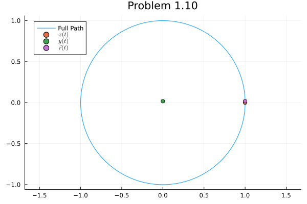

```julia
using Plots

R = 1
ω = 1

r_x(t) = R*cos(ω*t)
r_y(t) = R*sin(ω*t)

anim = @animate for i in 1:2:360
    plot(r_x, r_y, 0, 2*π/ω, aspect_ratio=:equal, label="Full Path", title="Problem 1.10")
    scatter!([r_x(i*pi/180)], [0], label="\$x(t)\$")
    scatter!([0], [r_y(i*pi/180)], label="\$y(t)\$")
    scatter!([r_x(i*pi/180)], [r_y(i*pi/180)], label="\$\\vec{r}(t)\$")
end

gif(anim, fps=30)
```

The particle's velocity is the time derivative of the position and the acceleration is the second time derivative: $$ \dfrac{d}{dt} \vec{r} = \dot{\vec{r}} = -\hat{x} \omega R \sin(\omega t) + \hat{y} \omega R \cos(\omega t) $$ $$ \dfrac{d^2}{dt^2} \vec{r} = {\ddot{\vec{r}}} = -\hat{x} \omega^2 R \cos(\omega t) - \hat{y} \omega^2 R \sin(\omega t) $$

The magnitude of the acceleration $|\ddot{\vec{r}}| = \sqrt{\omega^4 R^2 \cos^2(\omega t) + \omega^4 R^2 \sin^2(\omega t)} = \sqrt{\omega^4 R^2} = \omega^2 R$.

Since $\omega$ is the angular speed it is related to the linear speed $v$ by the equation $\omega R = v$ which gives us the $|\ddot{\vec{r}}| = v^2/R$.

The direction of acceleration is exactly negative of the position direction. You can check this. This matches the classic circular motion equation.

## Problem 1.17 **

**(a)** Prove that the vector product $ \vec{r} \times \vec{s} $ as defined by (1.9) is distributive; that is, that $$ \vec{r} \times (\vec{u} + \vec{v}) = \vec{r} \times \vec{u} + \vec{r} \times \vec{v} $$

**(b)** Prove the product rule: $$ \dfrac{d}{dt}(\vec{r} \times \vec{s}) = \vec{r} \times \dfrac{d\vec{s}}{dt} + \dfrac{d\vec{r}}{dt} \times \vec{s} $$

*(1.9)* The coss product is defined as $\vec{r} \times \vec{s} = \vec{p}$ where: $$ p_x = r_y s_z - r_z s_y \\ p_y = r_z s_x - r_x s_z \\ p_z = r_x s_y - r_y s_x $$

We also have the determinant mnemonic: $$ \vec{r} \times \vec{s} = \det \begin{bmatrix} \hat{x} & \hat{y} & \hat{z}\\ r_x & r_y & r_z \\ s_x & s_y & s_z \end{bmatrix} $$

### Solution

**(a)** We can first just do the $x$ component. $$ (\vec{r} \times (\vec{u} + \vec{v}))_x \\ = r_y (\vec{u} + \vec{v})_z - r_z (\vec{u} + \vec{v})_y \\ = r_y (u_z + v_z) - r_z (u_y + v_y) \\ = r_y u_z + r_y v_z - r_z u_y - r_z v_y \\ = (r_y u_z - r_z u_y) + (r_y v_z - r_z v_y) \\ = (\vec{r} \times \vec{u})_x + (\vec{r} \times \vec{v})_x $$

and we can repeat this for the other components.

**(b)** We can look at one component of $\dfrac{d}{dt} (\vec{r} \times \vec{s})$.

$$ \dfrac{d}{dt} (\vec{r} \times \vec{s})_x \\ = \dfrac{d}{dt} (r_y s_z) - \dfrac{d}{dt} (r_z s_y) \\ = \dot{r_y} s_z + r_y \dot{s_z} - \dot{r_z} s_y - r_z \dot{s_y} \\ = (\dot{r_y} s_z - \dot{r_z} s_y) + (r_y \dot{s_z} - r_z \dot{s_y}) \\ = (\dot{\vec{r}} \times \vec{s})_x + (\vec{r} \times \dot{\vec{s}})_x $$

And something symmetric is happening to the other components.

## Problem 1.19 **

If $\vec{r}$, $\vec{v}$, $\vec{a}$ denote the position, velocity, and acceleration of a particle, prove that $$ \dfrac{d}{dt} [\vec{a} \cdot (\vec{v} \times \vec{r})] = \dot{\vec{a}} \cdot (\vec{v} \times \vec{r}) $$

### Solution

At first thi might appear to be the case of someone forgetting to properly apply the chain rule or product rule, but before you look at the solution, remember that $$ \vec{v} = \dot{\vec{r}} \\ \vec{a} = \ddot{\vec{r}} $$

Here is the solution, and we can use 1.17 part (b): $$ \tfrac{d}{dt} [\vec{a} \cdot (\vec{v} \times \vec{r})] \\ = \dot{\vec{a}} \cdot (\vec{v} \times \vec{r}) + \vec{a} \cdot \tfrac{d}{dt}(\vec{v} \times \vec{r})\\ = \dot{\vec{a}} \cdot (\vec{v} \times \vec{r}) + \vec{a} \cdot (\vec{v} \times \tfrac{d\vec{r}}{dt} + \tfrac{d\vec{v}}{dt} \times \vec{r}) $$

This then can all be rewritten using the $\vec{r}$, $\vec{v}$, and $\vec{a}$ values: $$ \dot{\vec{a}} \cdot (\vec{v} \times \vec{r}) + \vec{a} \cdot (\vec{v} \times \vec{v} + \vec{a} \times \vec{r}) \\ = \dot{\vec{a}} \cdot (\vec{v} \times \vec{r}) + \vec{a} \cdot (\vec{v} \times \vec{v}) + \vec{a} \cdot (\vec{a} \times \vec{r}) $$

The second term becomes 0 since the cross product of any vector with itself is zero. The third term becomes 0 since the result of the cross product will be perpendicular to each of its two vectors and that vector will be perpendicular to $\vec{a}$; the dot product of two perpendicular vectors is zero.

$$ \frac{d}{dt} [\vec{a} \cdot (\vec{v} \times \vec{r})] = \dot{\vec{a}} \cdot (\vec{v} \times \vec{r}) $$

## Problem 1.29 *

Go over the steps from Equation (1.25) to (1.29) in the proof of conservation of momentum but treat the case of $N=4$ and write out all the summations explicitly to be sure you understand the various manipulations. *(page 20)*

## Problem 1.30 *

Conservation laws, such as the conservation of momentum, often give a surprising amount of information about the possible outcome of an experiment. Here is perhaps the simplest example: Two objects of masses $m_1$ and $m_2$ are subjects to no external forces. Object 1 is traveling with velocity $\vec{v}$ when it collides with the stationary object 2. The two objects stick together and move off with the common velocity $\vec{v}'$. Use the conservation of momentum to find $\vec{v}'$ in terms of $\vec{v}$, $m_1$, $m_2$

### Solution

We start by considering the initial total momentum $\vec{P_0}$ and the final momention $\vec{P_f}$. $$ \vec{P_0} = m_1 \vec{v} \\ \vec{P_f} = (m_1 + m_2) \vec{v}' $$

By conservation of momentum we can solve for $\vec{v}'$. $$ \vec{P_0} = \vec{P_f} \\ \Rightarrow m_1 \vec{v} = (m_1 + m_2) \vec{v}' \\ \Rightarrow \vec{v}' = \frac{m_1 \vec{v}}{m_1 + m_2} $$

#### Extra Thoughts

This particular case is also interesting for another reason. If we consider energy, and do not assume it is not conserved, then we start with $T_0$ and will end with $T_f$. $$ T_0 = \tfrac{1}{2} m_1 v^2 \\ T_f = \tfrac{1}{2} m_1 {v_1}^2 + \tfrac{1}{2} m_2 {v_2}^2 $$ We then know that when we have an interaction we will produce a final momentum of $P_f = m_1 v = m_1 v_1 + m_2 v_2$. we can relate $v_1$ to $v_2$ by the equation: $$ \frac{m_1 v - m_1 v_1}{m_2} = v_2 $$ This then can be put back into the equation for total final energy: $$ T_f = \tfrac{1}{2} m_1 {v_1}^2 + \tfrac{1}{2} m_2 {(\frac{m_1 v - m_1 v_1}{m_2})}^2 $$ We know that we cannot increase energy beyond the total initial energy, but there are cases where we lose energy to the surrounding. What if we wanted to know the situtation that minimizes the final energy. We do this by taking the derivative of $T_f$ with respect to $v_1$ and setting it to $0$. $$ \tfrac{d}{dv_1} [\tfrac{1}{2} m_1 {v_1}^2 + \tfrac{1}{2} \tfrac{(m_1 v - m_1 v_1)^2}{m_2}] \\ = m_1 v_1 + \tfrac{(m_1 v - m_1 v_1)}{m_2}(- m_1) \\ = m_1 v_1 - \tfrac{m_1}{m_2} m_1 v + \tfrac{m_1}{m_2} m_1 v_1 \\ = m_1 (1 + \tfrac{m_1}{m_2}) v_1 - \tfrac{{m_1}^2}{m_2} v = 0 \\ \Rightarrow m_1 (1 + \tfrac{m_1}{m_2}) v_1 = \tfrac{m_1^2}{m_2} v \\ \Rightarrow v_1 = \tfrac{m_1}{m_2+ {m_1}} v $$

And voila! We see the same speed as $v'$ from the question. This is the situation that maximizes energy loss without having momentum leave the system (aka perfectly inellastic collision).

## Problem 1.35 *

## Problem 1.38 *

You lay a rectangular board on the horizontal floor and then tilt the board about one edge until it slopes at an angle $\theta$ with the horizontal. Choose your origin at one of the two corners that touch the floor, the $x$ axis pointing along the bottom edge of the board, the $y$ axis pointing up the slope, and the $z$ axis normal to the board. You now kick a frictionless puck that is resting at $O$ so that it slides across the board with initial velocity $(v_{0x}, v_{0y}, 0)$. Write down Newton's second law using the given coordinates and then find how long the puck takes to return to the floor level and how far it is from $O$ when it does so.

### Solution

We see that there is a gravity force with components n the $y$ and $z$ directions and a normal force in the $z$ direction. When we look at the gravity component we can see that it breaks into: $$ {g_x} = 0 \\ {g_y} = -g \sin(\theta) \\ {g_z} = -g \cos(\theta) $$ and the normal force is $\vec{N}$ entirely in the $z$ direction. The normal force should act in such a way that cancels out $g_z$. This only leaves the acceleration $g_y$. I will show the way to get the kinematic equation, but this should probably be very familiar and doing the integral should not be necessary. Remember when integrating you have to include the "$+c$" which comes here in the form of the initial velocity and initial position. $$ \ddot{y} = -g \sin(\theta) \\ \int{\ddot{y}} \space dt = \int [-g \sin(\theta)] \space dt \\ \dot{y} = -g \sin(\theta)t + v_{0y}\\ \int \dot{y} \space dt = \int [-g \sin(\theta)t + v_{0y}] \space dt \\ y = -g \sin(\theta) \tfrac{1}{2} t^2 + v_{0y}t + y_0\\ y(t) = - \tfrac{1}{2} g \sin(\theta) t^2 +v_{0y}t + y_0\\ $$ We want to know how far from the origin the puck ends up. This means after the puck slides down the board, we want to know how far across the board (in the $x$ direction) the puck slid. We get this by finding the time it takes to get back down the board: $$ y(t) = 0 = - \tfrac{1}{2} g \sin(\theta) t^2 + v_{0y} t \\ \Rightarrow t = \frac{2 v_{0y}}{g \sin(\theta)}, $$ Since $x(t)$ is only influenced by the initial $x$ velocity $v_{0x}$ we just multiply this time by that: $$ x_{final} = \frac{2 v_{0x} v_{0y}}{g \sin(\theta)} $$

```
┌ Info: Saved animation to /tmp/jl_jEj4XIT6Xo.gif
└ @ Plots /home/trlarkin/.julia/packages/Plots/du2dt/src/animation.jl:156
```

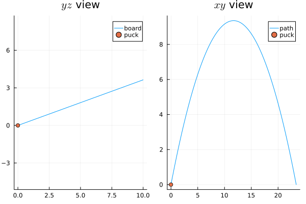

```julia
using Plots

θ = 20 * pi/180 # rad
v_0x = 5.0 # m/s
v_0y = 8.0 # m/s
g = 10

xs = 0:10
board(x) = tan(θ) * x
t_final = 2*v_0y/(g*sin(θ))

x_(t) = v_0x * t
y_(t) = -0.5*g*sin(θ)*t^2 + v_0y*t
z_(t) = tan(θ) * y_(t)


anim = @animate for t in range(0, t_final, length=100)
    plot(xs, board, aspect_ratio=:equal, label="board", layout=2, title="\$yz\$ view")
    scatter!([y_(t)*cos(θ)], [y_(t)*sin(θ)], label="puck")

    plot!(x_, y_, 0, t_final, subplot=2, label="path", title="\$xy\$ view")
    scatter!([x_(t)], [y_(t)], subplot=2, label="puck")
end

gif(anim, fps=30)
```

## Problem 1.39 **

## Problem 1.46 **

Consider the experiment of problem 1.27, in which a frictionless puck is slid straight across a rotating turntable through the center $O$. **(a)** Write down the polar coordinates ($r$, $\phi$) of the puck as a function of time, as measured in the inertial frame $\mathcal{S}$ of an observer on the ground. **(b)** Now write done the polar coordinates ($r'$, $\phi '$) of the puck measured by an observer (frame $\mathcal{S}'$) at rest on the turntable. Sketch the path.

### Solution

**(a)** We are frictionless, and on a flat surface... so by Newton's law, an object with no forces will just proceed with the initial velocity $v_0$. This will look be: $$ \vec{v} = v_0 \hat{r} \\ \vec{r} = (v_o t - R)\hat{r} $$ **(b)** While the second situation is the same event, it is viewed differently now that our coordinate system is rotating. This is called a *non-inertial reference frame*. Here we as the observer see an imaginary acceleration $\vec{a_i}$ on the puck due to our movement. There are a few cases to think about:

- If the puck is in the middle, we will still not see it moving.
- If the puck had no velocity we would just see it rotating around us.

Since we are rotating around the center, and the velocity is towards the center, these two actions will be linearly independent. We can also say that $\dot{\phi} = \omega$. $$ \dot{\phi'} = -\omega \\ \phi' = -\omega t \\ r' = v_o t - R $$ I wrote some code to generate what this will look like for different values of $\omega$. You see that they always start at the same point and always pass through $O$.

```julia
using Plots

v₀ = 2.0
R = 1.0

num_of_step = 1000

# here
r(t) = v₀ * t - R
θ(t) = 0

r′(t) = v₀ * t - R
θ′(t) = -ω*t

dt = 2*R/(v₀*num_of_step)

i = num_of_step

ω = pi/4
p1 = plot(θ, r,(0:i)*dt,  proj = :polar, title="\$ ω = \\pi/4 \$ rad/s", label=false, lims=(0,1))
plot!(θ′, r′,(0:i)*dt,  proj = :polar, label=false)

ω = pi
p2 = plot(θ, r,(0:i)*dt,  proj = :polar, title="\$ ω = \\pi \$ rad/s", label=false, lims=(0,1))
plot!(θ′, r′,(0:i)*dt,  proj = :polar, label=false)

ω = 2*pi
p3 = plot(θ, r,(0:i)*dt,  proj = :polar, title="\$ ω = 2\\pi \$ rad/s", label=false, lims=(0,1))
plot!(θ′, r′,(0:i)*dt,  proj = :polar, label=false)

ω = 15
p4 = plot(θ, r,(0:i)*dt,  proj = :polar, title="\$ ω = 15 \$ rad/s", label=false, lims=(0,1))
plot!(θ′, r′,(0:i)*dt,  proj = :polar, label=false)

plot(p1, p2, p3, p4, layout=4, )
```

[figure not shown]

## Problem 1.49 **